# Auckland Rugby Project - Trend Analysis of GPS Data

### Position 9: Scrum-half

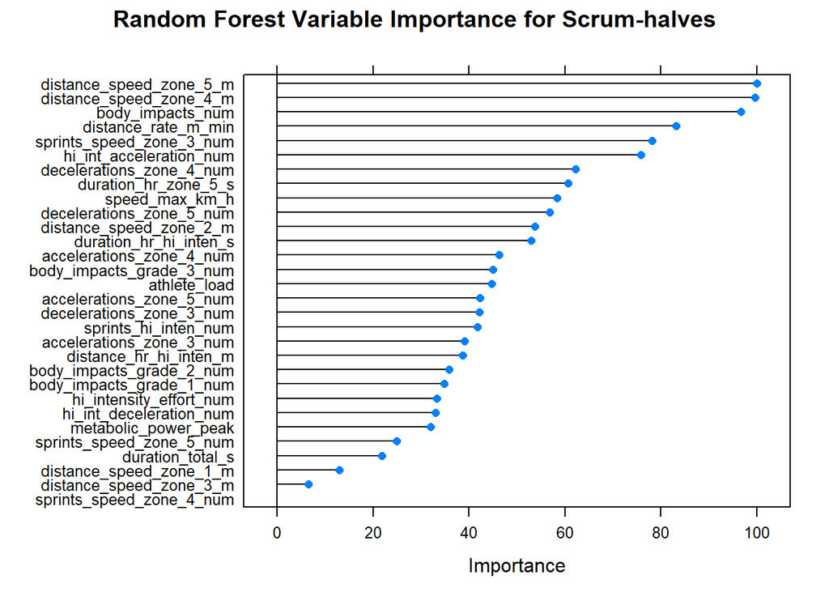

```r
set.seed(1)

ranger2.9 <- train(margins ~ .,
                   data = clean_names(pos9data),
                   method = "ranger",
                   importance = "permutation",
                   trControl = ctrl,
                   verbose = TRUE)
plot(varImp(ranger2.9), main = "Random Forest Variable Importance for Scrum-halves")
```

According to this variable importance plot, the top 5 variables for a scrum-half by permutation importance are:

1. `Distance Speed Zone 5 (m)`
2. `Distance Speed Zone 4 (m)`
3. `Body Impacts (num)`
4. `Distance Rate (m/min)`
5. `Sprints Speed Zone 3 (num)`

Comparing this with the top 5 variables from backward stepwise selection, only #3 `Sprints Speed Zone 3 (num)` is shared, being the 5th-most important variable in this random forest model. #1 `Decelerations Zone 4 (num)` is considered the 7th-most important variable, #2 `Distance Speed Zone 3 (m)` the 29th-most important (and second-least in this subset of variables), #4 `Duration HR Hi-Inten (s)` the 12th-most important, and #5 `Decelerations Zone 5 (num)` the 10th-most important.

### Position 10: Fly-half

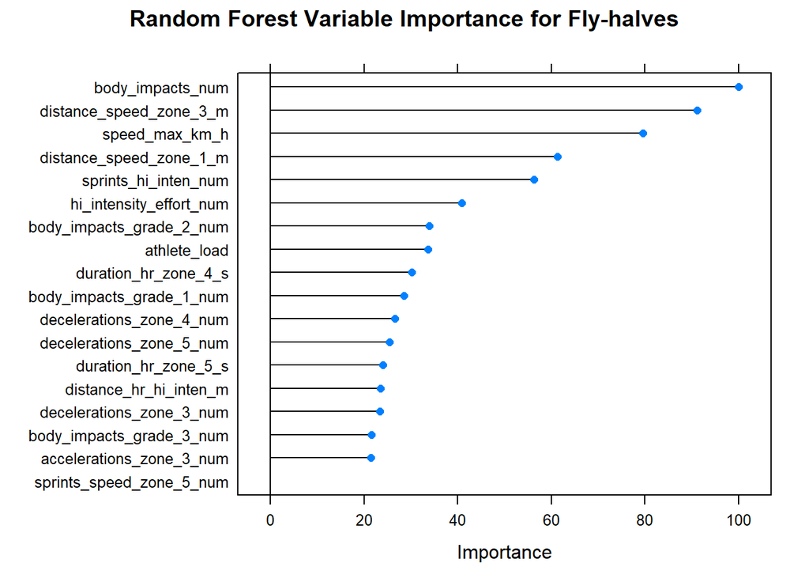

```r
set.seed(1)

ranger2.10 <- train(margins ~ .,
                   data = clean_names(pos10data),
                   method = "ranger",
                   importance = "permutation",
                   trControl = ctrl,
                   verbose = TRUE)
plot(varImp(ranger2.10), main = "Random Forest Variable Importance for Fly-halves")
```

According to this variable importance plot, the top 5 variables for a fly-half by permutation importance are:

1. `Body Impacts (num)`
2. `Distance Speed Zone 3 (m)`
3. `Speed Max (km/h)`
4. `Distance Speed Zone 1 (m)`
5. `Sprints Hi-Inten (num)`

Comparing this with the top 5 variables from backward stepwise selection, #1 `Sprints Hi-Inten (num)`, #4 `Distance Speed Zone 3 (m)` and #5 `Body Impacts (num)` appear in the top 5 for the random forest model (at 5th-most important, 2nd-most important and most important respectively). #2 `Decelerations Zone 3 (num)` is considered the 15th-most important variable, and #3 `Decelerations Zone 4 (num)` is considered the 11th-most important.

### Position 11: Left wing

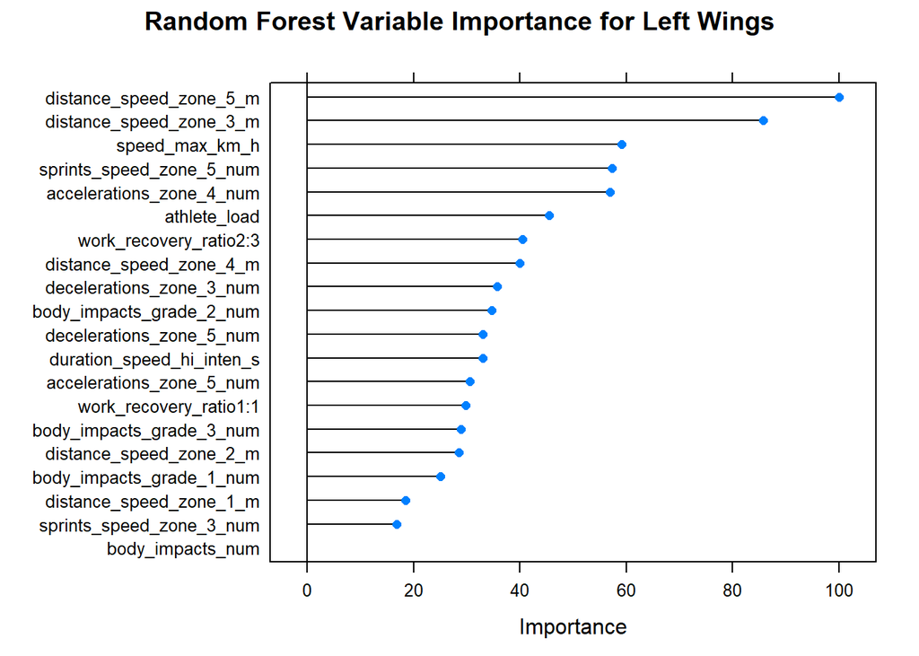

```r
set.seed(1)

ranger2.11 <- train(margins ~ .,
                   data = clean_names(pos11data),
                   method = "ranger",
                   importance = "permutation",
                   trControl = ctrl,
                   verbose = TRUE)
plot(varImp(ranger2.11), main = "Random Forest Variable Importance for Left Wings")
```

According to this variable importance plot, the top 5 variables for a left wing by permutation importance are:

1. `Distance Speed Zone 5 (m)`
2. `Distance Speed Zone 3 (m)`
3. `Speed Max (km/h)`
4. `Sprints Speed Zone 5 (num)`
5. `Accelerations Zone 4 (num)`

Comparing this with the top 5 variables from backward stepwise selection, #1 `Distance Speed Zone 3 (m)` and #5 `Distance Speed Zone 5 (m)` are present on the top 5 for the random forest model, at 2nd-most and most important. #2 `Work Recovery Ratio` | 2:3 is considered the 7th-most important variable, #3 `Decelerations Zone 3` the 9th-most important, and #4 `Decelerations Zone 5` the 11th-most important.

### Position 12: Inside centre

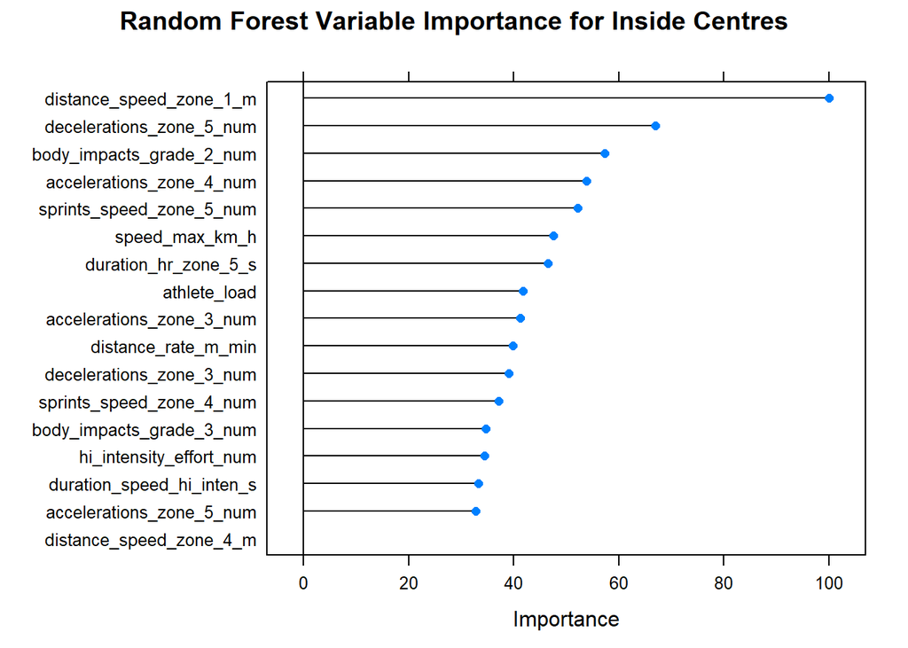

```r
set.seed(1)

ranger2.12 <- train(margins ~ .,
                   data = clean_names(pos12data),
                   method = "ranger",
                   importance = "permutation",
                   trControl = ctrl,
                   verbose = TRUE)
plot(varImp(ranger2.12), main = "Random Forest Variable Importance for Inside Centres")
```

According to this variable importance plot, the top 5 variables for an inside centre by permutation importance are:

1. `Distance Speed Zone 1 (m)`
2. `Decelerations Zone 5 (num)`
3. `Body Impacts Grade 2 (num)`
4. `Accelerations Zone 4 (num)`
5. `Sprints Speed Zone 5 (num)`

Comparing this with the top 5 variables from backward stepwise selection, #1 `Distance Speed Zone 1 (m)`, #4 `Body Impacts Grade 2 (num)` and #5 `Decelerations Zone 5 (num)` are present on the top 5 for the random forest model, at most, 3rd-most and 2nd-most important. #2 `Athlete Load` is considered the 8th-most important variable, and #3 `Sprints Speed Zone 4 (num)` the 12th-most important.

### Position 13: Outside centre

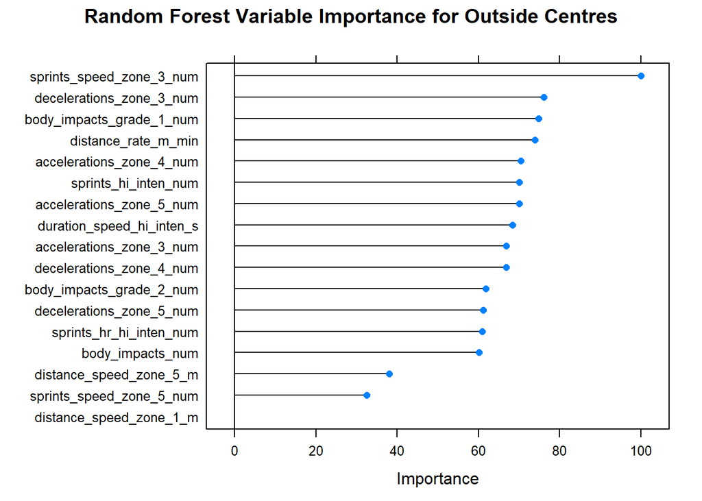

```r
set.seed(1)

ranger2.13 <- train(margins ~ .,
                   data = clean_names(pos13data),
                   method = "ranger",
                   importance = "permutation",
                   trControl = ctrl,
                   verbose = TRUE)
plot(varImp(ranger2.13), main = "Random Forest Variable Importance for Outside Centres")
```

According to this variable importance plot, the top 5 variables for an outside centre by permutation importance are:

1. `Sprints Speed Zone 3 (num)`
2. `Decelerations Zone 3 (num)`
3. `Body Impacts Grade 1 (num)`
4. `Distance Rate (m/min)`
5. `Accelerations Zone 4 (num)`

Comparing this with the top 5 variables from backward stepwise selection, #1 `Sprints Speed Zone 3 (num)`, #3 `Decelerations Zone 3 (num)`, #4 `Accelerations Zone 4 (num)` and #5 `Body Impacts Grade 1 (num)` are present on the top 5 for the random forest model, at most, 2nd-most, 5th-most and 3rd-most important. #2 `Body Impacts (num)` is considered the 14th-most important variable here.

### Position 14: Right wing

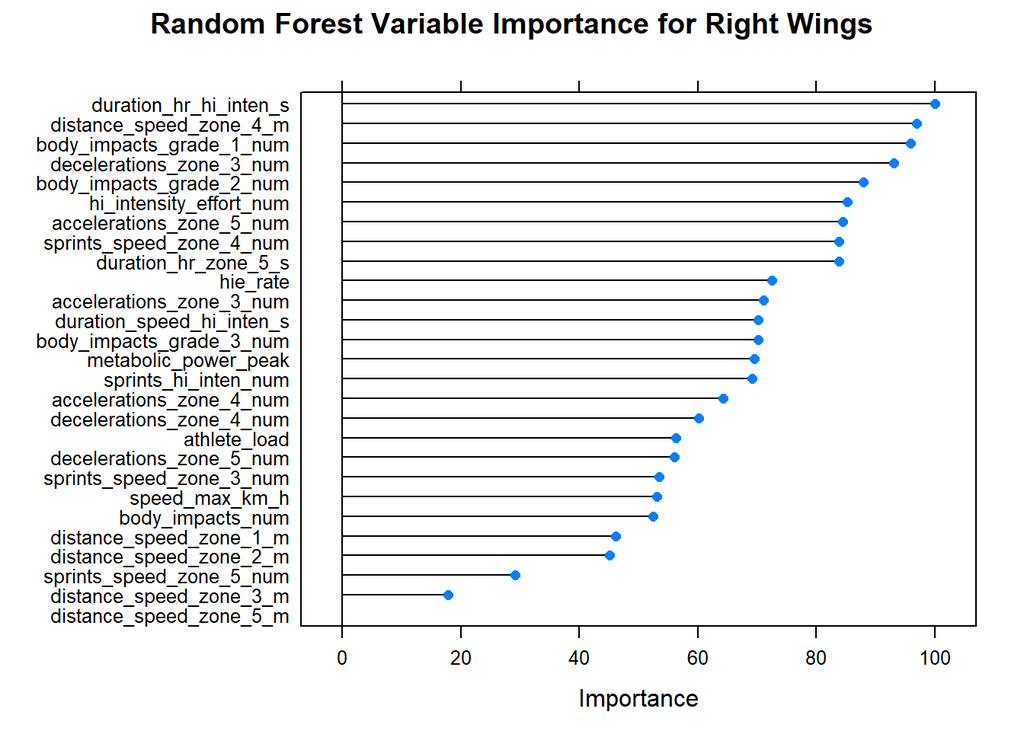

```r
set.seed(1)

ranger2.14 <- train(margins ~ .,
                   data = clean_names(pos14data),
                   method = "ranger",
                   importance = "permutation",
                   trControl = ctrl,
                   verbose = TRUE)
plot(varImp(ranger2.14), main = "Random Forest Variable Importance for Right Wings")
```

According to this variable importance plot, the top 5 variables for an right wing by permutation importance are:

1. `Duration HR Hi-Inten (s)`
2. `Distance Speed Zone 4 (m)`
3. `Body Impacts Grade 1 (num)`
4. `Decelerations Zone 3 (num)`
5. `Body Impacts Grade 2 (num)`

Comparing this with the top 5 variables from backward stepwise selection, only #4 `Body Impacts Grade 2 (num)` made the top 5 for the random forest model, at 5th-most important. #1 `HIE Rate` is considered the 10th-most important variable, #2 `Body Impacts Grade 3 (num)` the 13th-most important, #3 `Duration HR Zone 5 (s)` the 9th-most important, and #5 `Accelerations Zone 4 (num)` the 16th-most important.

### Position 15: Fullback

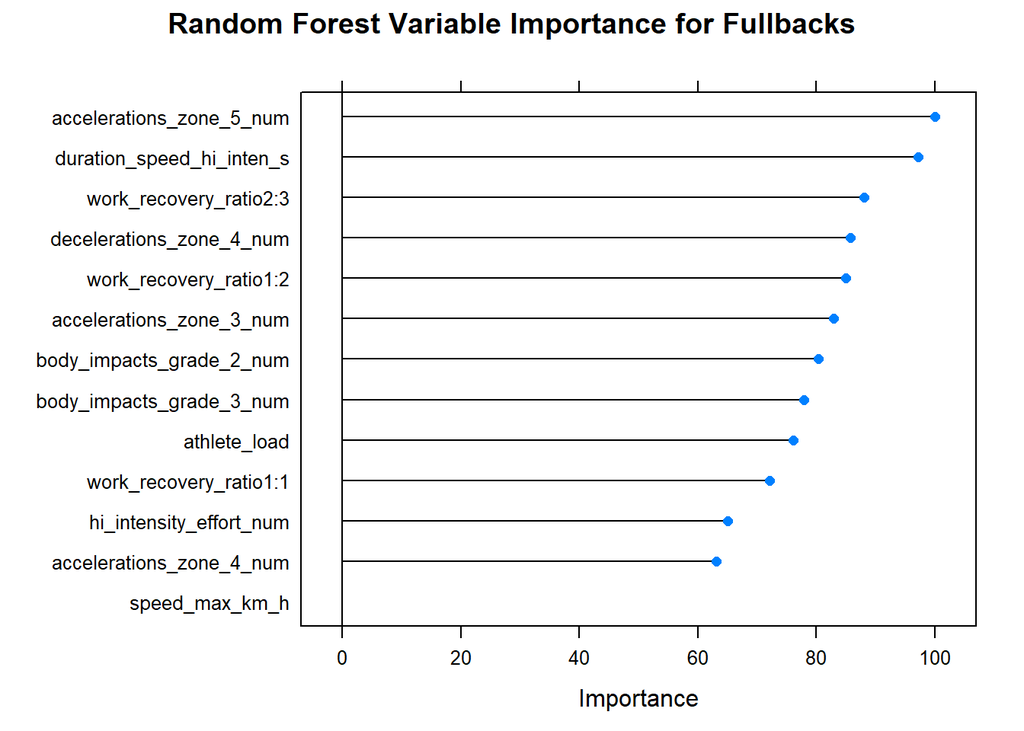

```r
set.seed(1)

ranger2.15 <- train(margins ~ .,
                   data = clean_names(pos15data),
                   method = "ranger",
                   importance = "permutation",
                   trControl = ctrl,
                   verbose = TRUE)
plot(varImp(ranger2.15), main = "Random Forest Variable Importance for Fullbacks")
```

According to this variable importance plot, two dummy variables for `Work Recovery Ratio` are in the top 5 variables by permutation importance. So instead, the top 6 variables are taken, to obtain five unique variables. The top 6 variables for a fullback by permutation importance are:

1. `Accelerations Zone 5 (num)`
2. `Duration Speed Hi-Inten (s)`
3. `Work Recovery Ratio` | 2:3
4. `Decelerations Zone 4 (num)`
5. `Work Recovery Ratio` | 1:2
6. `Accelerations Zone 3 (num)`

Comparing this with the top 5 variables from backward stepwise selection, #2 `Work Recovery Ratio` | 1:2, #3 `Accelerations Zone 3 (num)` and #5 `Duration Speed Hi-Inten (s)` are present in the top 6 for the random forest model, at 5th-most, 6th-most and 2nd-most important. #1 `Body Impacts Grade 2 (num)` is considered the 7th-most important variable, and #4 `Hi Intensity Effort (num)` the 11th-most important.

# Concluding thoughts

The top five variables for the front row appear to be dominated by acceleration, deceleration and distance measures. Body impact measures are also considered important. Distance measures being important, particularly in Speed Zones, is interesting, considering the front row is not necessarily expected to make quick long runs.

The top five variables for the back row appear to be dominated by body impact measures, sprints, speed, acceleration and deceleration measures. Body impacts being considered important is expected, since the back row are a good combination of size, physicality and speed, and so are able to make more tackles against larger opponents.

The top five variables for the halves appear to be dominated by speed, sprints, distance and body impact measures. Scrum-half surprisingly registered several data points of `Sprints Hi-Inten (num)` that are all higher than every other value, skewing the distribution significantly.

The top five variables for the centres appear to be dominated by body impact measures, sprints, speed, acceleration and deceleration measures. Inside centre, in particular was found to be particularly strong for body impact, acceleration and deceleration measures - higher distribution than back row players for body impacts, and higher distribution centres than some of the wings and fullback acceleration and deceleration measures.

The top five variables for the wings and fullback appear to be speed, acceleration and deceleration measures. This makes sense, since they are expected to cover large distances very quickly. The acceleration and deceleration measures being considered important may have to do with their ability to sidestep players during their runs.

I wanted to apply XGBoost, lasso regression and possibly elastic net models to this data, but initial testing presented me with errors in running the code. I estimated that the time it would take to troubleshoot these would take much longer than I can afford, unfortunately. I have enjoyed getting to work with this data, however, pushing my personal skills beyond what I’ve done in my courses.

Thank you, Auckland Rugby, for this opportunity to work with real world data in an industry setting. It has been valuable experience, and I hope you are satisfied with what has been presented here.